# Comp90024 A2 Deployment & Fission Guide

Xinyao Li – Group 36

### 1. Cluster Setup and Check connect

After receiving the Kubernetes config file from a teammate, we first set up the local environment to connect to the cluster.

1. Install required tools

```bash
brew install kubectl
brew install helm
brew install fission-cli
```

2. Configure kubeconfig

```bash
mkdir -p ~/.kube
cp /path/to/config ~/.kube/config
chmod 600 ~/.kube/config
```

3. Check Kubernetes cluster connection

```bash
kubectl get nodes
kubectl get svc
```

4. Check Elasticsearch

```bash
kubectl get svc -n elastic
kubectl get svc -A | grep -i elastic
```

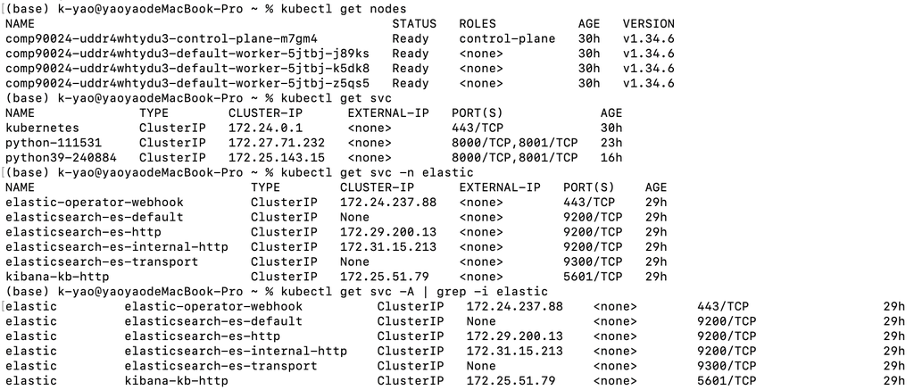

```bash
kubectl get secret elasticsearch-es-elastic-user -n elastic \
-o go-template='{{.data.elastic | base64decode}}'
```

6. Check Fission ( Use 1.22 version)

```bash
fission version
kubectl get all -n fission
```

7. Create Fission Environment ( Use 3.9 version to avoid 3.7 incompatibility issues)

```bash
fission env create \
  --name python39 \
  --builder fission/python-builder-3.9 \
  --image fission/python-env-3.9
```

### 2. Fission - Backend Data Pipeline

##### Prerequisites

- Kubernetes cluster (MRC / NeCTAR)
- kubectl configured
- Fission CLI installed (Serverless Functions)
- Elasticsearch deployed in K8s (Data storage & analytics)

### 2.1 BlueSky Harvester

The system continuously harvests BlueSky data related to Australia (fuel, cost of living, etc.) and stores it in Elasticsearch for further analysis.

##### I. Crawling Strategy

The Bluesky harvester uses a combination of historical crawling and real-time incremental crawling.

- The crawler logs in to the Bluesky API and selects a small batch of queries in each run.
- Historical posts are collected using the `until` parameter.
  - The crawler gradually moves backwards in time and stores the history cursor in Elasticsearch.
- New posts are collected using the `since` parameter.
  - Only posts newer than the last collected timestamp are fetched.
- Raw posts are cleaned and converted into structured Elasticsearch documents.
- The Bluesky post URI is used as the Elasticsearch document ID to prevent duplicate data.
- Cursor states are stored in the `bluesky-cursors` index, while collected social media posts are stored in the shared `social-posts` index.
- The post URI is used as the Elasticsearch document ID to avoid duplicate records when multiple crawlers write to the same index.

This design supports continuous real-time updates while gradually completing historical data collection without exceeding the Fission timeout.

##### III. Bluesky Dataset Fields

The processed Bluesky dataset contains both original post attributes and additional analytical features generated during preprocessing.

| Field | Type | Description |
| --- | --- | --- |
| `url` | string | Unique URI of the Bluesky post and Elasticsearch document ID |
| `text` | text | Main textual content of the post |
| `author` | string | Bluesky user handle |
| `query` | string | Search keyword used during crawling |
| `created_at` | datetime | Original post creation timestamp |
| `date` | date | Extracted date used for aggregation |
| `platform` | string | Source platform identifier (`bluesky`) |
| `ingested_at` | datetime | Elasticsearch ingestion timestamp |
| `like` | integer | Number of likes |
| `reply` | integer | Number of replies |
| `repost` | integer | Number of reposts |
| `is_fuel` | boolean | Fuel-topic indicator |
| `is_cost` | boolean | Cost-of-living topic indicator |
| `is_au` | boolean | Australia-related indicator |
| `sentiment_score` | float | VADER sentiment score |
| `sentiment_label` | string | Sentiment category |
| `matched_location` | string | Detected Australian region |

Additional engineered features were generated during preprocessing to support downstream analysis and dashboard visualisation.

| Engineered Feature | Description |
| --- | --- |
| `sentiment_score` | Continuous VADER compound sentiment score ranging from `-1` to `1` |
| `sentiment_label` | Sentiment category derived from the sentiment score (`positive`, `neutral`, `negative`) |
| `matched_location` | Australian state or region inferred using keyword-based location matching |
| `is_fuel` | Boolean indicator showing whether the post is related to fuel or petrol topics |
| `is_cost` | Boolean indicator showing whether the post is related to cost-of-living topics |
| `is_au` | Boolean indicator showing whether the post is related to Australia |

#### Step 1. Create Secret (Hidden)

(And also can create Configmap, but I didn’t use it.)

Optional: Check Secret Yaml

```bash
kubectl get secret es-secret -o yaml
```

#### Step 2. Upload zip file

Before create new zip, Check or Delete existing zip code file.

```bash
rm -f bluesky-harvester.zip
```

```bash
zip -r bluesky-harvester.zip \
  bluesky_harvester.py \
  bluesky_processor.py \
  bluesky_storager.py \
  requirements.txt
```

#### Step 3. Create Package

Before create new package, Check or Delete existing package.

```bash
fission package list
fission package delete --name bluesky-pkg
```

Then, Create Fission Package

```bash
fission package create \
  --name bluesky-pkg \
  --env python39 \
  --sourcearchive bluesky-harvester.zip
```

Wait for a few seconds, Confirm Package Succeeded instead of Running.

#### Step 4. Create Function

Before create, Check OR Delete existing package.

```bash
fission fn list
fission fn delete --name bluesky-harvester
```

Then, Create Fission Function

```bash
fission fn create \
  --name bluesky-harvester \
  --pkg bluesky-pkg \
  --env python39 \
  --entrypoint "bluesky_harvester.main" \
  --secret es-secret \
  --fntimeout 120
```

#### Step 5. Test Fission Function

```bash
fission fn test --name bluesky-harvester --timeout 5m
```

Expected output: {“saved”:xxx,“status”:“ok”,“total”:xxx}. Then create a timer to automatically capture:

#### Step 6. Create Timer

```bash
fission timer create \
  --name bluesky-timer \
  --function bluesky-harvester \
  --cron "@every 2m"
#OR --cron "*/2 * * * *"
```

Check:

```bash
fission timer list
fission fn logs --name bluesky-harvester (optional)
```

#### Step 7. Connect ElasticSearch

(Local for check output)

```bash
kubectl port-forward -n elastic svc/elasticsearch-es-http 9200:9200
```

Expect Output:

```bash
Forwarding from 127.0.0.1:9200 -> 9200
Forwarding from [::1]:9200 -> 9200
```

**Open a new terminal window and check the status of the write to ES.**

##### 7.1 Reset Data / Cursor (Important for Testing)

1. Reset cursor only (Recommended for testing)

```bash
curl -k -u elastic:elastic -X DELETE https://localhost:9200/bluesky-cursors
```

- This resets the Bluesky crawler progress only. Existing post data in `social-posts` will remain.
- Use this when you changed the code and want the crawler to re-run history crawling.
2. Full reset from scratch

```bash
#(old verssion) curl -k -u elastic:elastic -X DELETE https://localhost:9200/bluesky-posts
curl -k -u elastic:elastic -X DELETE https://localhost:9200/social-posts
curl -k -u elastic:elastic -X DELETE https://localhost:9200/bluesky-cursors
```

- This deletes both the stored data and the crawling progress.
- Use this only when you want to start completely from zero.

#### Step 8. Check Data

Next time you reopen, just check:

```bash
# The total number of data that have been collected and are being written to ES.
curl -k -u elastic:elastic "https://localhost:9200/social-posts/_count"

# Checks how many Bluesky records have been written into the shared social-posts index.
curl -k -u elastic:elastic \ "https://localhost:9200/social-posts/_count?q=platform:bluesky"
```

Expected output: {“count”:xxx,“_shards”:{“total”:x,“successful”:x,“skipped”:x,“failed”:x}}.

#### Step 9. Overall Update Deployment

**If you modify the .py code file, you need to update zip, package, function and re-run the test.**

```bash
# 1. Repackage after modifying the code
rm -f bluesky-harvester.zip
zip -r bluesky-harvester.zip \
  bluesky_harvester.py \
  bluesky_processor.py \
  bluesky_storager.py \
  requirements.txt

# 2. Update package
fission package update \
  --name bluesky-pkg \
  --sourcearchive bluesky-harvester.zip

# 3. Update function
fission fn update \
  --name bluesky-harvester \
  --entrypoint "bluesky_harvester.main" \
  --secret es-secret \
  --fntimeout 120


# Optional: Delete the old functions and packages
fission timer delete --name bluesky-timer
fission fn delete --name bluesky-harvester
fission package delete --name bluesky-pkg

# Create a new package
fission package create \
  --name bluesky-pkg \
  --env python39 \
  --sourcearchive bluesky-harvester.zip

# Rebuild the function and add a 120-second function timeout
fission fn create \
  --name bluesky-harvester \
  --pkg bluesky-pkg \
  --env python39 \
  --entrypoint "bluesky_harvester.main" \
  --secret es-secret \
  --fntimeout 120

# 4. Delete the entire Elasticsearch index (clear all data + reset crawler state)
# old version : curl -k -u elastic:elastic -X DELETE https://localhost:9200/bluesky-posts
curl -k -u elastic:elastic -X DELETE https://localhost:9200/social-posts
curl -k -u elastic:elastic -X DELETE https://localhost:9200/bluesky-cursors

# 5. Simple test. If there are no issues, then use timer
time fission fn test --name bluesky-harvester --timeout 2m

# 6. Create timer for automatic capture
fission timer create \
  --name bluesky-timer \
  --function bluesky-harvester \
  --cron "@every 2m"
```

#### Step10. Generate Fission Specs (Optional)

Fission specs can be used to save deployment configurations into YAML files for reproducible deployment.

```bash
# i. Initialize Spec Directory
rm -rf specs
fission spec init

# ii. Generate Package Spec
fission package create \
  --spec \
  --name bluesky-pkg \
  --env python39 \
  --sourcearchive bluesky-harvester.zip

# iii. Generate Function Spec
fission fn create \
  --spec \
  --name bluesky-harvester \
  --pkg bluesky-pkg \
  --env python39 \
  --entrypoint "bluesky_harvester.main" \
  --secret es-secret \
  --fntimeout 120

# iv. Generate Timer Spec
fission timer create \
  --spec \
  --name bluesky-timer \
  --function bluesky-harvester \
  --cron "@every 2m"

# v. Apply Specs
# Before applying specs, delete existing resources to avoid conflicts.
fission timer delete --name bluesky-timer
fission fn delete --name bluesky-harvester
fission package delete --name bluesky-pkg

# Then apply:
fission spec apply

# vi. Test Function
time fission fn test --name bluesky-harvester --timeout 2m
```

#### IV. Issues & Fixes

During deployment, several issues were encountered:

- Package stuck in `running` → caused by heavy dependencies such as `pandas`, which significantly slowed down Fission package builds.
- Package failed → caused by Python version incompatibility with the default Fission Python 3.7 environment.
- Function timeout → caused by attempting to crawl large amounts of historical data in a single execution.
- Bluesky API `429 Too Many Requests` → caused by frequent login requests and short timer intervals.

Solutions:

- Removed `pandas` from both the crawler logic and `requirements.txt`;
- Switched to a Python 3.9 Fission environment;
- Implemented incremental crawling with small query batches and cursor tracking;
- - Replaced the rate-limited Bluesky account and updated the Kubernetes secret credentials.

These improvements made the pipeline stable and compatible with Fission serverless execution.

#### V. Index Update Note

The original Bluesky-only index was `bluesky-posts`. It was later changed to the shared index `social-posts` so that Bluesky and Reddit social media data can be stored under the same schema and queried together in Kibana.

To support this shared index design:

- all social media documents include a `platform` field, such as `bluesky` or `reddit`;
- Bluesky records are queried with `platform:bluesky`;
- Reddit records are queried with `platform:reddit`;
- crawler progress is still stored separately in `bluesky-cursors`, because cursor state is only used by the Bluesky crawler.

### 2.2 Official FuelPrice Harvester

The system harvests historical retail fuel price data from the Western Australia (WA) FuelWatch API. It focuses on the Unleaded Petrol (ULP) time series to support cost-of-living and social media correlation analysis.

##### i. Data Processing Logic

- **Source**: Automated download of monthly retail fuel CSV reports from the FuelWatch WA API.
- **Cleaning**: Filters raw data for `PRODUCT_DESCRIPTION == "ULP"` to isolate unleaded petrol records.
- **Aggregation**: Computes daily average prices across all stations, reducing millions of raw records into a structured daily time series.
- **Incremental Mode**: Uses a `MAX_FILES` constraint to process data in smaller batches, preventing Fission execution timeouts during the initial backfill.

##### ii. Deployment Steps (Hongkun Zhang’s work)

#### Step 1. Build and Package

Create the deployment archive for the FuelWatch pipeline.

```bash
# Zip the script and requirements
zip -r fuelwatch-harvester.zip \
  fuelwatch_fission.py \
  requirements.txt
```

#### Step 2. Create Fission Resources

Deploy the code as a serverless function

```bash
# Create Fission Package
fission package create \
  --name fuelwatch-pkg \
  --env python39 \
  --sourcearchive fuelwatch-harvester.zip

# Create Fission Function
fission fn create \
  --name fuelwatch-harvester \
  --pkg fuelwatch-pkg \
  --env python39 \
  --entrypoint "fuelwatch_fission.main" \
  --fntimeout 120
```

#### Step 3. Test and Execution

```bash
# Test the function with an extended timeout
fission fn test --name fuelwatch-harvester --timeout 3m
```

Expected output: {“status”: “ok”, “monthly_files_attempted”: 2, “daily_records”: xx, “saved”: xx}.

#### Step 4. Check Data in ElasticSearch

Verify that the aggregated time series data has been indexed successfully.

```bash
curl -k -u elastic:elastic "https://localhost:9200/fuelwatch-dev/_count"
```

Expected output: {“count”:xxxx,“_shards”:{“total”:x,“successful”:x,“skipped”:x,“failed”:x}}

#### III. Issues Encountered & Fixes

- **Fission Environment Variable Limitation**:
  - **Issue**: Attempting to pass `MAX_FILES` via the Fission CLI (`--env MAX_FILES=2`) failed to trigger correctly in the runtime.
  - **Solution**: Switched to a hardcoded default value within the script and relied on local code logic for incremental ingestion control.
- **Large Dataset Execution Timeout**:
  - **Issue**: Processing 4.3 million raw records from the historical API exceeded the default Fission timeout, causing `request timeout` errors.
  - **Solution**: Implemented **Incremental Ingestion** by limiting the function to process only 2 monthly files per run (`MAX_FILES = 2`) and extended the test timeout to 3 minutes (`--timeout 3m`).
- **Storage Optimization**:
  - **Issue**: High memory usage when processing full CSV files in a container.
  - **Solution**: Performed pre-aggregation (computing daily averages) before writing to Elasticsearch, significantly reducing the indexing load and storage footprint.

### 3. Kibana Data Visualization

#### step 1: Connect Kibana

```bash
kubectl port-forward svc/kibana-kb-http -n elastic 5601:5601
```

Expect Output:

```bash
Forwarding from 127.0.0.1:5601 -> 5601
Forwarding from [::1]:5601 -> 5601
```

**Open in your local browser: https://localhost:5601**

You can view the real-time captured data, will see table-like view of the data (similar to Excel).

#### step 2: Login

```bash
Username: elastic
Password: elastic
```

#### step 3: Create Data View

Left side Navigate to:

```bash
Stack Management → Data Views → Create data view
```

**Fill in to see Bluesky data:**

```bash
Name: bluesky
Index pattern: social-posts #(old version bluesky-posts)
Time field: created_at # or ingested_at
```

**Fill in to see Fuel Prices data ( Hongkun’s work ):**

```bash
Name: fuelwatch
Index pattern: fuelwatch-*
Time field: date
```

**Note:** Unlike BlueSky data which uses `created_at`, FuelWatch uses the calculated `date` field from the daily price aggregation.

#### step 4: Explore Data

```bash
For Social Media:  Discover → Select "bluesky"
For Fuel Prices:   Discover → Select "fuelwatch"
```

### 4. GitLab Workflow for Bluesky Backend

#### Step1. Set up GitLab SSH access

Run the following commands to generate an SSH key and print the public key:

```bash
ssh-keygen -t ed25519 -C "UserName@student.unimelb.edu.au"

Prompt to enter the password three times: `Press Enter`

# Then print the public key:
cat ~/.ssh/id_ed25519.pub
```

Copy output like: `ssh-ed25519 XXXXX...XXXX UserName@student.unimelb.edu.au`

Add it to GitLab: `GitLab → Edit profile → SSH Keys → Add new key`

After adding the key, test the SSH connection:

```bash
ssh -T git@gitlab.unimelb.edu.au
```

#### Step2. Clone repository

```bash
mkdir -p ~/git
cd ~/git
git clone git@gitlab.unimelb.edu.au:JUNYAOZ5/comp90024_team_36.git
```

Enter the local repository:

```bash
cd ~/Documents/COMP90024/cccAsm2/git/comp90024_team_36

# Check the current branch
git branch
```

#### Step3: Create new branch & Add files

```bash
git checkout -b feature/bluesky
```

Create the backend folder:

```bash
mkdir -p backend/bluesky
```

Copy the Bluesky Fission files into the Git repository:

```bash
cp ~/Documents/COMP90024/cccAsm2/2.Fission\ Harvester/bluesky-harvester.zip backend/bluesky/
cp ~/Documents/COMP90024/cccAsm2/2.Fission\ Harvester/requirements.txt backend/bluesky/
cp ~/Documents/COMP90024/cccAsm2/2.Fission\ Harvester/bluesky_harvester.py backend/bluesky/
cp ~/Documents/COMP90024/cccAsm2/2.Fission\ Harvester/bluesky_processor.py backend/bluesky/
cp ~/Documents/COMP90024/cccAsm2/2.Fission\ Harvester/bluesky_storager.py backend/bluesky/
cp -R ~/Documents/COMP90024/cccAsm2/2.Fission\ Harvester/specs backend/bluesky/

# Check whether the files were copied successfully
ls backend/bluesky
ls backend/bluesky/specs
```

#### Step4. Commit and Push to GitLab

```bash
# Stage all files
git add backend/bluesky
# Check the files before committing
git status
# Commit the changes
git commit -m "Add Bluesky backend pipeline"
git push origin feature/bluesky
```

#### Step5. Upload the R Markdown and HTML files

Enter the local Git repository:

```bash
cd ~/Documents/COMP90024/cccAsm2/git/comp90024_team_36
```

Copy the `.Rmd` and `.html` files into the repository:

```bash
cp ~/Documents/COMP90024/cccAsm2/CCCA2Deployment\ Guide.Rmd .
cp ~/Documents/COMP90024/cccAsm2/CCCA2Deployment-Guide.html .

ls
```

Stage and upload the files to GitLab:

```bash
git add "CCCA2Deployment Guide.Rmd"
git add CCCA2Deployment-Guide.html
git status
git commit -m "Add deployment guide report"
git push
```

#### If Rename and Update Branch

Rename the local branch:

```bash
# Rename the local branch:
git branch -m feature/xinyao-bluesky
# Push the renamed branch to GitLab:
git push origin feature/xinyao-bluesky
# Delete the old remote branch:
git push origin --delete feature/bluesky
# Set the upstream tracking branch:
git push --set-upstream origin feature/xinyao-bluesky
# Delete old branch:
git push origin --delete feature/bluesky
# Check the final branch:
git branch
```

#### Step 6. Update Deployment Guide Files in GitLab

After modifying the `.Rmd` deployment guide locally, the updated `.Rmd` and generated `.html` files were copied into the GitLab repository `docs/` directory and pushed to GitLab.

Enter the local Git repository:

```bash
cd "/Users/k-yao/Documents/COMP90024/cccAsm2/git/comp90024_team_36_clean"
# Copy the updated files into docs/:
cp ~/Documents/COMP90024/cccAsm2/CCCA2Deployment\ Guide.Rmd docs/
cp ~/Documents/COMP90024/cccAsm2/CCCA2Deployment-Guide.html docs/
# Check the updated files:
ls docs
# Stage, commit and push the updates:
git add docs/
git status
git commit -m "Update deployment guide docs"
git push
```

#### Step7. Re-clone Latest GitLab Repository

After merging the Bluesky backend into `main`, re-clone the latest repository to keep the local project clean and synchronised with teammates’ updates.

##### 1. Go to local git directory

```bash
cd ~/Documents/COMP90024/cccAsm2/git
```

##### 2. Clone latest repository

```bash
git clone git@gitlab.unimelb.edu.au:JUNYAOZ5/comp90024_team_36.git comp90024_team_36_clean
```

##### 3. Enter the new repository

```bash
cd comp90024_team_36_clean
```

##### 4. Check branch

```bash
git branch
```

Expected branch:

```
main
```

##### 5. Pull latest updates

```bash
git pull origin main
```

The latest repository should now contain:

```
backend/fission/reddit
backend/fission/bluesky
```

##### 6. Optional: Remove old local repository

After confirming the new repository works correctly:

```bash
rm -rf ~/Documents/COMP90024/cccAsm2/git/comp90024_team_36
```

##### 7. Future update workflow

For future modifications:

```bash
git checkout main
git pull origin main
git checkout -b feature/update-name
```

Modify files under:

```
backend/fission/bluesky/
```

Then commit and push:

```bash
git add .
git commit -m "Update Bluesky backend"
git push origin feature/update-name
```

Finally, create a new Merge Request:

```
feature/update-name → main
```